# INN_project_MaryamShokoufi

**Background and Context:**

The ability to process visual information using machine learning algorithms can be very useful as demonstrated in various applications. The Street View House Numbers (SVHN) dataset is one of the most popular ones. It has been used in neural networks created by Google to read house numbers and match them to their geolocations. This is a great benchmark dataset to play with, learn and train models that accurately identify street numbers, and incorporate them into all sorts of projects.

**Objective:**

In this project, we will use a dataset with images centered around a single digit (many of the images do contain some distractors at the sides). Although we are taking a sample of the data which is simple, it is more complex than MNIST because of the distractors. Given the dataset, our aim is to build a model that can identify house numbers in an image.

**Dataset:**

The dataset has the following features:

- Number of classes: 10
- Training data: 42000 images
- Testing data: 18000 images

```python
# importing the required packages and loading the .h5 type data file using the h5py package
import h5py
import numpy as np
import pandas as pd
import seaborn as sns
import matplotlib.pyplot as plt

from numpy.random import seed

from sklearn import model_selection
from sklearn.model_selection import GridSearchCV, train_test_split
from sklearn.preprocessing import LabelEncoder, OneHotEncoder
from sklearn.compose import ColumnTransformer
from sklearn.metrics import confusion_matrix
from sklearn.pipeline import Pipeline

import tensorflow as tf
from tensorflow.keras.models import Sequential
from tensorflow.keras.layers import Dense
from tensorflow.keras.utils import to_categorical
from tensorflow.keras.callbacks import ModelCheckpoint, ReduceLROnPlateau
from tensorflow.keras import losses
from tensorflow.keras import optimizers



from keras.layers import Dense, Input, Dropout
from keras.wrappers.scikit_learn import KerasClassifier
from keras.models import Sequential
from keras.utils import np_utils
import numpy as np
import warnings
warnings.filterwarnings("ignore")
```

```python
from google.colab import drive
drive.mount('/content/drive')
```

```python
# Open the file as readonly
h5f = h5py.File('/content/drive/My Drive/Colab Notebooks/INN_project/SVHN_single_grey1.h5', 'r')
# Load the training, test and validation set
x_train = h5f['X_train'][:]
y_train = h5f['y_train'][:]
x_test = h5f['X_test'][:]
y_test = h5f['y_test'][:]
# Close this file
h5f.close()
```

## Visualizing images from our data

```python
print(x_train.shape)
print(x_test.shape)
print(y_train.shape)
print(y_test.shape)
```

```
(42000, 32, 32)
(18000, 32, 32)
(42000,)
(18000,)
```

```
label for each of the above image: [2 6 7 4 4 0 3 0 7 3]
```

```python
# visualizing the first 10 images in the dataset and their labels
%matplotlib inline
import matplotlib.pyplot as plt
plt.figure(figsize=(10, 1))
for i in range(10):
    plt.subplot(1, 10, i+1)
    plt.imshow(x_train[i], cmap="gray")
    plt.axis('off')
plt.show()
print('label for each of the above image: %s' % (y_train[0:10]))
```

[output not shown]

## Normalizing our train and test data

```python
# Flatten the images
image_vector_size = 32*32
x_train = x_train.reshape(x_train.shape[0], image_vector_size)
x_test = x_test.reshape(x_test.shape[0], image_vector_size)

# # normalize inputs from 0-255 to 0-1
x_train = x_train / 255.0
x_test = x_test / 255.0

print('Training set', x_train.shape, y_train.shape)
print('Test set', x_test.shape, y_test.shape)
```

```
Training set (42000, 1024) (42000,)
Test set (18000, 1024) (18000,)
```

## OHE the target variables

```python
# Convert to "one-hot" vectors using the to_categorical function
num_classes = 10
y_train = to_categorical(y_train, num_classes)
y_test_cat=to_categorical(y_test,num_classes)
```

```python
print("First 5 training lables as one-hot encoded vectors:\n", y_train[:5])
```

```
First 5 training lables as one-hot encoded vectors:
 [[0. 0. 1. 0. 0. 0. 0. 0. 0. 0.]
 [0. 0. 0. 0. 0. 0. 1. 0. 0. 0.]
 [0. 0. 0. 0. 0. 0. 0. 1. 0. 0.]
 [0. 0. 0. 0. 1. 0. 0. 0. 0. 0.]
 [0. 0. 0. 0. 1. 0. 0. 0. 0. 0.]]
```

## Definfing the sequential Model

```python
# define model

image_size=32*32

# create model
model = Sequential()

model.add(Dense(256, activation='relu',kernel_initializer='he_uniform',input_shape=(image_size,))) ###Multiple Dense units with Relu activation

model.add(Dense(64, activation='relu',kernel_initializer='he_uniform'))
model.add(Dense(64, activation='relu',kernel_initializer='he_uniform'))
model.add(Dense(32, activation='relu',kernel_initializer='he_uniform'))

model.add(Dense(num_classes, activation='softmax')) ### For multiclass classification Softmax is used
```

```python
# Compile model

adam = optimizers.Adam(lr=1e-3)
model.compile(loss=losses.categorical_crossentropy, optimizer=adam, metrics=['accuracy']) ### Loss function = Categorical cross entropy
## Looking into our base model
model.summary()
```

```
Model: "sequential"
_________________________________________________________________
 Layer (type)                Output Shape              Param #
=================================================================
 dense (Dense)               (None, 256)               262400

 dense_1 (Dense)             (None, 64)                16448

 dense_2 (Dense)             (None, 64)                4160

 dense_3 (Dense)             (None, 32)                2080

 dense_4 (Dense)             (None, 10)                330

=================================================================
Total params: 285,418
Trainable params: 285,418
Non-trainable params: 0
_________________________________________________________________
```

```python
checkpoint = ModelCheckpoint("model_weights.h5",monitor='val_accuracy',
                            save_weights_only=True, mode='max',verbose=1)
reduce_lr = ReduceLROnPlateau(monitor='val_loss',factor=0.1,patience=2,min_lr=0.01,model='auto')

callbacks = [checkpoint,reduce_lr]
```

```python
# Fit the model
history=model.fit(x_train, y_train, validation_split=0.2, epochs=40, batch_size=128, verbose=2,callbacks=callbacks)
```

```
Epoch 1: saving model to model_weights.h5
263/263 - 4s - loss: 2.2498 - accuracy: 0.1446 - val_loss: 2.1207 - val_accuracy: 0.2137 - lr: 0.0010 - 4s/epoch - 17ms/step

Epoch 2: saving model to model_weights.h5
263/263 - 1s - loss: 1.8791 - accuracy: 0.3306 - val_loss: 1.6350 - val_accuracy: 0.4411 - lr: 0.0010 - 1s/epoch - 5ms/step

Epoch 3: saving model to model_weights.h5
263/263 - 1s - loss: 1.5695 - accuracy: 0.4565 - val_loss: 1.4600 - val_accuracy: 0.5036 - lr: 0.0010 - 1s/epoch - 4ms/step

Epoch 4: saving model to model_weights.h5
263/263 - 1s - loss: 1.4340 - accuracy: 0.5142 - val_loss: 1.3902 - val_accuracy: 0.5373 - lr: 0.0010 - 1s/epoch - 4ms/step

Epoch 5: saving model to model_weights.h5
263/263 - 1s - loss: 1.3146 - accuracy: 0.5654 - val_loss: 1.2540 - val_accuracy: 0.5945 - lr: 0.0010 - 1s/epoch - 5ms/step

Epoch 6: saving model to model_weights.h5
263/263 - 1s - loss: 1.2345 - accuracy: 0.6044 - val_loss: 1.1841 - val_accuracy: 0.6238 - lr: 0.0010 - 1s/epoch - 4ms/step

Epoch 7: saving model to model_weights.h5
263/263 - 1s - loss: 1.1579 - accuracy: 0.6321 - val_loss: 1.1629 - val_accuracy: 0.6337 - lr: 0.0010 - 1s/epoch - 5ms/step

Epoch 8: saving model to model_weights.h5
263/263 - 1s - loss: 1.1223 - accuracy: 0.6438 - val_loss: 1.0889 - val_accuracy: 0.6595 - lr: 0.0010 - 1s/epoch - 5ms/step

Epoch 9: saving model to model_weights.h5
263/263 - 1s - loss: 1.0639 - accuracy: 0.6698 - val_loss: 1.0766 - val_accuracy: 0.6631 - lr: 0.0010 - 1s/epoch - 5ms/step

Epoch 10: saving model to model_weights.h5
263/263 - 1s - loss: 1.0387 - accuracy: 0.6754 - val_loss: 1.0026 - val_accuracy: 0.6885 - lr: 0.0010 - 1s/epoch - 4ms/step

Epoch 11: saving model to model_weights.h5
263/263 - 1s - loss: 1.0104 - accuracy: 0.6840 - val_loss: 1.0324 - val_accuracy: 0.6742 - lr: 0.0010 - 1s/epoch - 5ms/step

Epoch 12: saving model to model_weights.h5
263/263 - 1s - loss: 1.0045 - accuracy: 0.6846 - val_loss: 1.0160 - val_accuracy: 0.6806 - lr: 0.0010 - 1s/epoch - 4ms/step

Epoch 13: saving model to model_weights.h5
263/263 - 1s - loss: 0.9680 - accuracy: 0.6982 - val_loss: 1.1269 - val_accuracy: 0.6369 - lr: 0.0010 - 1s/epoch - 5ms/step

Epoch 14: saving model to model_weights.h5
```

[output cut: 64 more lines]

```

Epoch 36: saving model to model_weights.h5
263/263 - 1s - loss: 0.6901 - accuracy: 0.7826 - val_loss: 0.7728 - val_accuracy: 0.7640 - lr: 0.0010 - 1s/epoch - 4ms/step

Epoch 37: saving model to model_weights.h5
263/263 - 1s - loss: 0.6766 - accuracy: 0.7881 - val_loss: 0.7903 - val_accuracy: 0.7586 - lr: 0.0010 - 1s/epoch - 5ms/step

Epoch 38: saving model to model_weights.h5
263/263 - 1s - loss: 0.6650 - accuracy: 0.7915 - val_loss: 0.8102 - val_accuracy: 0.7542 - lr: 0.0010 - 1s/epoch - 4ms/step

Epoch 39: saving model to model_weights.h5
263/263 - 1s - loss: 0.6745 - accuracy: 0.7892 - val_loss: 0.7567 - val_accuracy: 0.7762 - lr: 0.0010 - 1s/epoch - 5ms/step

Epoch 40: saving model to model_weights.h5
263/263 - 1s - loss: 0.6588 - accuracy: 0.7942 - val_loss: 0.7749 - val_accuracy: 0.7642 - lr: 0.0010 - 1s/epoch - 5ms/step
```

```python
y_pred=model.predict(x_test)
```

```python
y_pred_final=[]
for i in y_pred:
  y_pred_final.append(np.argmax(i))
```

```python
from sklearn.metrics import classification_report
print(classification_report(y_test,y_pred_final))
```

```
              precision    recall  f1-score   support

           0       0.82      0.79      0.80      1814
           1       0.75      0.82      0.78      1828
           2       0.79      0.79      0.79      1803
           3       0.76      0.70      0.73      1719
           4       0.77      0.84      0.81      1812
           5       0.74      0.66      0.70      1768
           6       0.77      0.69      0.73      1832
           7       0.82      0.80      0.81      1808
           8       0.61      0.77      0.68      1812
           9       0.79      0.72      0.75      1804

    accuracy                           0.76     18000
   macro avg       0.76      0.76      0.76     18000
weighted avg       0.76      0.76      0.76     18000
```

**Tuning Model**

```python
# Adding dropout to our model and reducing learning rate

image_size=32*32

# create model
model = Sequential()

model.add(Dense(256, activation='relu',kernel_initializer='he_uniform',input_shape=(image_size,))) ###Multiple Dense units with Relu activation

model.add(Dense(64, activation='relu',kernel_initializer='he_uniform'))
model.add(Dense(64, activation='relu',kernel_initializer='he_uniform'))
model.add(Dropout(0.1))
model.add(Dense(32, activation='relu',kernel_initializer='he_uniform'))

model.add(Dense(num_classes, activation='softmax')) ### For multiclass classification Softmax is used
```

```python
# Compile model

adam = optimizers.Adam(lr=1e-3)
model.compile(loss=losses.categorical_crossentropy, optimizer=adam, metrics=['accuracy']) ### Loss function = Categorical cross entropy
```

```python
## Looking into our tuned model
model.summary()
```

```
Model: "sequential_3"
_________________________________________________________________
 Layer (type)                Output Shape              Param #
=================================================================
 dense_15 (Dense)            (None, 256)               262400

 dense_16 (Dense)            (None, 64)                16448

 dense_17 (Dense)            (None, 64)                4160

 dropout_3 (Dropout)         (None, 64)                0

 dense_18 (Dense)            (None, 32)                2080

 dense_19 (Dense)            (None, 10)                330

=================================================================
Total params: 285,418
Trainable params: 285,418
Non-trainable params: 0
_________________________________________________________________
```

```python
checkpoint = ModelCheckpoint("model_weights.h5",monitor='val_accuracy',
                            save_weights_only=True, mode='max',verbose=1)
reduce_lr = ReduceLROnPlateau(monitor='val_loss',factor=0.1,patience=2,min_lr=0.001,model='auto')

callbacks = [checkpoint,reduce_lr]
```

```python
# Fit the model
history=model.fit(x_train, y_train, validation_split=0.2, epochs=40, batch_size=128, verbose=2,callbacks=callbacks)
```

```
Epoch 1: saving model to model_weights.h5
263/263 - 2s - loss: 2.3098 - accuracy: 0.1030 - val_loss: 2.2891 - val_accuracy: 0.1598 - lr: 0.0010 - 2s/epoch - 8ms/step

Epoch 2: saving model to model_weights.h5
263/263 - 1s - loss: 2.2190 - accuracy: 0.1459 - val_loss: 2.1858 - val_accuracy: 0.1539 - lr: 0.0010 - 1s/epoch - 5ms/step

Epoch 3: saving model to model_weights.h5
263/263 - 1s - loss: 2.1193 - accuracy: 0.1768 - val_loss: 2.1049 - val_accuracy: 0.1794 - lr: 0.0010 - 1s/epoch - 5ms/step

Epoch 4: saving model to model_weights.h5
263/263 - 1s - loss: 1.9015 - accuracy: 0.2766 - val_loss: 1.6627 - val_accuracy: 0.4050 - lr: 0.0010 - 1s/epoch - 5ms/step

Epoch 5: saving model to model_weights.h5
263/263 - 1s - loss: 1.6089 - accuracy: 0.4164 - val_loss: 1.4856 - val_accuracy: 0.4930 - lr: 0.0010 - 1s/epoch - 4ms/step

Epoch 6: saving model to model_weights.h5
263/263 - 1s - loss: 1.4084 - accuracy: 0.5204 - val_loss: 1.2600 - val_accuracy: 0.5958 - lr: 0.0010 - 1s/epoch - 5ms/step

Epoch 7: saving model to model_weights.h5
263/263 - 1s - loss: 1.2479 - accuracy: 0.5934 - val_loss: 1.2115 - val_accuracy: 0.6079 - lr: 0.0010 - 1s/epoch - 5ms/step

Epoch 8: saving model to model_weights.h5
263/263 - 1s - loss: 1.1566 - accuracy: 0.6274 - val_loss: 1.0878 - val_accuracy: 0.6592 - lr: 0.0010 - 1s/epoch - 5ms/step

Epoch 9: saving model to model_weights.h5
263/263 - 1s - loss: 1.1051 - accuracy: 0.6490 - val_loss: 1.1086 - val_accuracy: 0.6465 - lr: 0.0010 - 1s/epoch - 5ms/step

Epoch 10: saving model to model_weights.h5
263/263 - 1s - loss: 1.0500 - accuracy: 0.6668 - val_loss: 1.0489 - val_accuracy: 0.6637 - lr: 0.0010 - 1s/epoch - 5ms/step

Epoch 11: saving model to model_weights.h5
263/263 - 1s - loss: 1.0180 - accuracy: 0.6779 - val_loss: 0.9858 - val_accuracy: 0.6919 - lr: 0.0010 - 1s/epoch - 4ms/step

Epoch 12: saving model to model_weights.h5
263/263 - 1s - loss: 0.9774 - accuracy: 0.6899 - val_loss: 0.9499 - val_accuracy: 0.7017 - lr: 0.0010 - 1s/epoch - 4ms/step

Epoch 13: saving model to model_weights.h5
263/263 - 1s - loss: 0.9424 - accuracy: 0.7020 - val_loss: 0.9335 - val_accuracy: 0.7046 - lr: 0.0010 - 1s/epoch - 5ms/step

Epoch 14: saving model to model_weights.h5
```

[output cut: 64 more lines]

```

Epoch 36: saving model to model_weights.h5
263/263 - 1s - loss: 0.6764 - accuracy: 0.7867 - val_loss: 0.7040 - val_accuracy: 0.7790 - lr: 0.0010 - 1s/epoch - 5ms/step

Epoch 37: saving model to model_weights.h5
263/263 - 1s - loss: 0.6747 - accuracy: 0.7866 - val_loss: 0.7592 - val_accuracy: 0.7627 - lr: 0.0010 - 1s/epoch - 4ms/step

Epoch 38: saving model to model_weights.h5
263/263 - 1s - loss: 0.6720 - accuracy: 0.7852 - val_loss: 0.7306 - val_accuracy: 0.7754 - lr: 0.0010 - 1s/epoch - 5ms/step

Epoch 39: saving model to model_weights.h5
263/263 - 1s - loss: 0.6625 - accuracy: 0.7893 - val_loss: 0.7467 - val_accuracy: 0.7639 - lr: 0.0010 - 1s/epoch - 4ms/step

Epoch 40: saving model to model_weights.h5
263/263 - 1s - loss: 0.6551 - accuracy: 0.7924 - val_loss: 0.7330 - val_accuracy: 0.7733 - lr: 0.0010 - 1s/epoch - 4ms/step
```

```python
# predicting the model on test data
y_pred=model.predict(x_test)
```

```python
y_pred[0]
```

```
array([0.43238884, 0.04481912, 0.01429042, 0.01592834, 0.0086019 ,
       0.03167741, 0.09636518, 0.0041063 , 0.2542486 , 0.09757395],
      dtype=float32)
```

```python
# As our outputs are probabilities so we will try to get the output class from these probablities by getting the maximum value
y_pred_final=[]
for i in y_pred:
  y_pred_final.append(np.argmax(i))
```

```python
y_pred_final[0]
```

```
0
```

## Generating classification report

```python
from sklearn.metrics import classification_report
print(classification_report(y_test,y_pred_final))
```

```
              precision    recall  f1-score   support

           0       0.74      0.84      0.78      1814
           1       0.74      0.83      0.79      1828
           2       0.79      0.78      0.79      1803
           3       0.70      0.77      0.73      1719
           4       0.89      0.78      0.83      1812
           5       0.77      0.75      0.76      1768
           6       0.84      0.72      0.77      1832
           7       0.83      0.80      0.82      1808
           8       0.76      0.73      0.74      1812
           9       0.73      0.74      0.73      1804

    accuracy                           0.77     18000
   macro avg       0.78      0.77      0.77     18000
weighted avg       0.78      0.77      0.77     18000
```

## Confusion Matrix

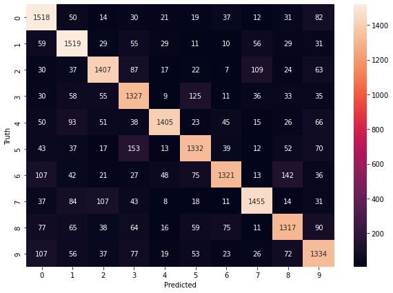

```python
from sklearn.metrics import confusion_matrix
import seaborn as sns

cm=confusion_matrix(y_test,y_pred_final)

plt.figure(figsize=(10,7))
sns.heatmap(cm,annot=True,fmt='d')
plt.xlabel('Predicted')
plt.ylabel('Truth')
plt.show()
```

## Misclassified images

```python
index = 0
misclassified_images = []
for label, predict in zip(y_test, y_pred_final):
    if label != predict:
        misclassified_images.append(index)
    index +=1
print(misclassified_images)
print(len(misclassified_images))
```

[output not shown]

## Predicting the output

```
Was predicted  4
Was labeled  6
Predicted Probabilities:  [[1.1475367e-02 3.5794983e-05 5.7593924e-03 7.8175459e-03 8.2227367e-01
  1.0120241e-02 8.4318534e-02 6.2990519e-03 9.8580793e-03 4.2042311e-02]]
```

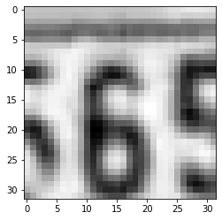

```python
image_index = 45
plt.imshow(x_test[image_index].reshape(32, 32),cmap='Greys')
pred = model.predict(x_test[image_index].reshape(-1, 1024))
print("Was predicted ",pred.argmax())
print("Was labeled ",y_test[image_index])
print("Predicted Probabilities: ",pred)
```

## Accuracy curve

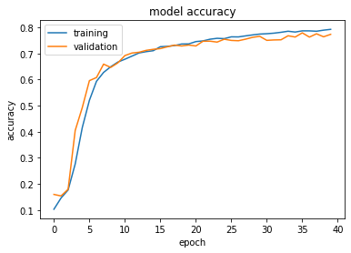

```python
loss, accuracy  = model.evaluate(x_test, y_test_cat, verbose=False)

plt.plot(history.history['accuracy'])
plt.plot(history.history['val_accuracy'])
plt.title('model accuracy')
plt.ylabel('accuracy')
plt.xlabel('epoch')
plt.legend(['training', 'validation'], loc='best')
plt.show()
```

**Conclusion**